# Steak Preference in the US

Summary Report For the **Mountain** Region

Dookyung Kim

Sunday, March, 11, 2018

## Background

In May 2014, Walt Hickey at [538.com](http://fivethirtyeight.com/) published an article entitled [“How Americans Like Their Steak”](https://fivethirtyeight.com/features/how-americans-like-their-steak/). This article utilized survey data collected from 550 people which asked questions related to various risky activities, such as whether they speed in traffic, if they smoke or go skydiving, and if they prefer a riskier lottery. The survey also asked if they eat steak and if so, how they prefer their steak.

## Purpose

The “steak survey” dataset that was used for the [“How Americans Like Their Steak”](https://fivethirtyeight.com/features/how-americans-like-their-steak/) article, is available through the R package [`fivethirtyeight`](https://cran.r-%20project.org/web/packages/fivethirtyeight/index.html). Using this dataset, this article summarizes the steak preferences for the **Mountain** Region of the United States by gender.

For our summary presented here, a subset of the original steak survey was extracted to only include responses with no missing data and only included respondents from the **Mountain** region of the US. The data subset used for our summary had 24 respondents.

## Demographic Summary Tables

The age categories of the 24 survey respondents were:

Ages of Survey Respondents

| Ages | % |
| --- | --- |
| 18-29 | 16.67 |
| 30-44 | 29.17 |
| 45-60 | 37.50 |
| > 60 | 16.67 |

The education levels of the 24 survey respondents were:

Education of Survey Respondents

| Education | % |
| --- | --- |
| Less than high school degree | 0.00 |
| High school degree | 4.17 |
| Some college or Associate degree | 41.67 |
| Bachelor degree | 33.33 |
| Graduate degree | 20.83 |

The income levels of the 24 survey respondents were:

Income of Survey Respondents

| Income | % |
| --- | --- |
| $0 - $24,999 | 8.33 |
| $25,000 - $49,999 | 16.67 |
| $50,000 - $99,999 | 50.00 |
| $100,000 - $149,999 | 12.50 |
| $150,000+ | 12.50 |
| TRUE | 0.00 |

## *OPTIONAL* Demographics of Survey Respondents in a Merged Table

This section is provided as an example of how to merge the three demographic summary tables for the 24 survey respondents above into a single merged table.

Demographics of Survey Respondents

| Ages Category | Ages % | Education Category | Education % | Income Category | Income % |
| --- | --- | --- | --- | --- | --- |
| 18-29 | 16.67 | Less than high school degree | 0.00 | $0 - $24,999 | 8.33 |
| 30-44 | 29.17 | High school degree | 4.17 | $25,000 - $49,999 | 16.67 |
| 45-60 | 37.50 | Some college or Associate degree | 41.67 | $50,000 - $99,999 | 50.00 |
| > 60 | 16.67 | Bachelor degree | 33.33 | $100,000 - $149,999 | 12.50 |
|  |  | Graduate degree | 20.83 | $150,000+ | 12.50 |
|  |  |  |  | TRUE | 0.00 |

## Steak Preparation Preference by Gender

Finally, here is a breakdown of the 24 survey respondents for the **Mountain** region of the US on how they prefer their steak to be prepared by gender.

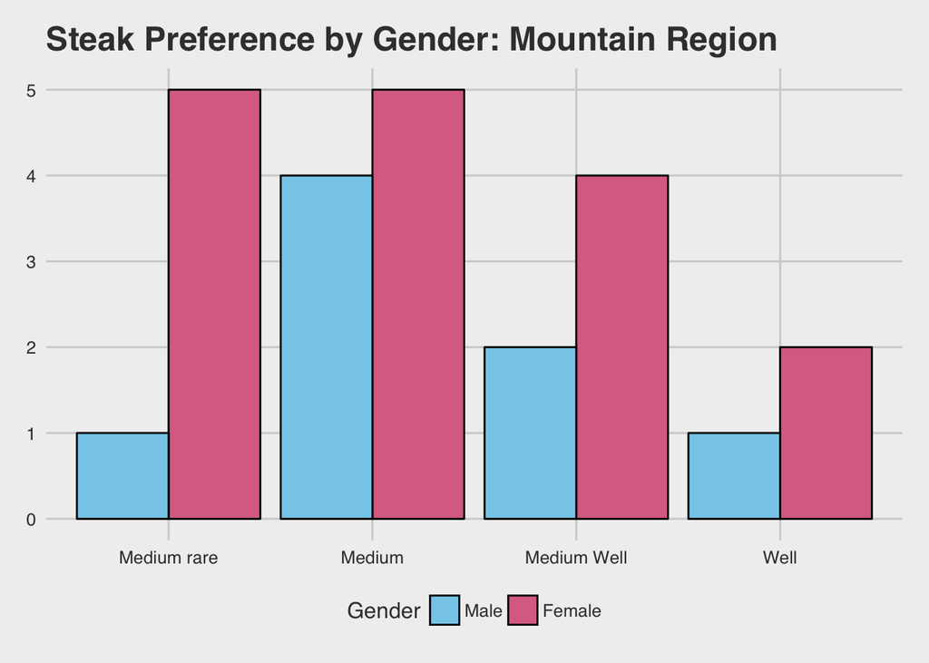